# Loans - Final Group Project

## c. KNN Model

The K-Nearest Neighbors (KNN) algorithm is a non-parametric, instance-based machine learning model used for classification and regression tasks. For classification, it works by identifying the `k` closest data points (neighbors) to a query point in the feature space and assigning the majority class of those neighbors to the query. The model relies heavily on the concept of distance (commonly Euclidean) and is sensitive to feature scaling. KNN is simple, intuitive, and effective for datasets where the relationship between features and target labels is not well-defined by a mathematical function.

```r
y_col <- which(colnames(train_scaled) == "y")
prediction_knn <- knn(train = train_scaled[,-y_col],
                      test = test_scaled[,-y_col],
                      cl = train_scaled[,y_col],
                      k = 1)
#summary(prediction_knn)

cm_knn <- confusionMatrix(as.factor(prediction_knn), as.factor(test_scaled$y), positive = "1")
cm_knn
```

```
## Confusion Matrix and Statistics
##
##           Reference
## Prediction     0     1
##          0   634  1085
##          1  1711 36674
##
##                Accuracy : 0.9303
##                  95% CI : (0.9277, 0.9328)
##     No Information Rate : 0.9415
##     P-Value [Acc > NIR] : 1
##
##                   Kappa : 0.2762
##
##  Mcnemar's Test P-Value : <2e-16
##
##             Sensitivity : 0.9713
##             Specificity : 0.2704
##          Pos Pred Value : 0.9554
##          Neg Pred Value : 0.3688
##              Prevalence : 0.9415
##          Detection Rate : 0.9145
##    Detection Prevalence : 0.9571
##       Balanced Accuracy : 0.6208
##
##        'Positive' Class : 1
##
```

Before the analysis of the results we wanted to explain the choice of the `k`. With a highly imbalanced dataset, the majority class dominates, and using a larger `k` could exacerbate this issue by allowing more majority-class neighbors to influence the classification decision. By setting `k = 1`, the model relies solely on the closest neighbor, which helps avoid amplifying the imbalance effect and allows the model to focus on the local behavior of individual data points.

The confusion matrix for the KNN model (k=1) provides the following insights:

1. **Accuracy**: The model achieved an accuracy of **93.03%**, which is good but slightly lower than the Logistic Regression model. This indicates that while the KNN model performs well overall, there is some room for improvement, particularly in handling the negative class.
2. **Kappa**: The Kappa statistic is **0.2762**, which reflects only fair agreement between predictions and actual values. This suggests that the model struggles to balance performance across the imbalanced classes.
3. **Sensitivity**: The sensitivity is **97.13%**, demonstrating that the model is highly effective at identifying loans that are likely to be repaid (positive class). This is critical for ensuring reliable predictions for the majority class.
4. **Specificity**: The specificity is **27.04%**, indicating that the model has significant difficulty identifying defaulted loans (negative class). This leads to a high number of false positives, highlighting the impact of the class imbalance.
5. **Positive Predictive Value (PPV)**: The PPV is **95.54%**, meaning that when the model predicts a loan will be repaid, it is correct most of the time. This is beneficial for decision-making on loan approvals.
6. **Balanced Accuracy**: The balanced accuracy, which averages sensitivity and specificity, is **62.08%**, reflecting moderate overall performance, but the model is biased toward the majority class.

The KNN model with `k=1` performs well in identifying loans likely to be repaid, as evidenced by its high sensitivity and PPV. However, it struggles to correctly classify defaulted loans, with low specificity and Kappa values. These weaknesses are likely due to the class imbalance and the use of `k=1`, which makes the model highly sensitive to local noise in the data. We attempted adjusting `k` to improve tis specificity, however, it did not work (likely due to the high imbalance already mentioned). Addressing the class imbalance (e.g., through resampling techniques) could improve the model’s performance in detecting the minority class, however we did not try to do it as we aim to use this regression on the stack model, and we need to maintain the same rows of train and test sets throughout all models to do so.

## d. ANN Model

An Artificial Neural Network (ANN) is a machine learning model inspired by the structure and functioning of the human brain. It consists of layers of interconnected nodes (neurons) that process input data through weighted connections. ANNs excel at modeling complex, non-linear relationships in data by learning patterns through backpropagation, where weights are adjusted iteratively to minimize errors. They are particularly powerful for tasks like image recognition, natural language processing, and predictive modeling, offering flexibility and adaptability for a wide range of problems.

```r
model_ann <- neuralnet(y ~ ., data = train_scaled, hidden = c(1), stepmax = 1e7, lifesign = "none", threshold = 0.1)
plot(model_ann)

prediction_ann <- predict(model_ann, newdata = test_scaled)
binary_prediction_ann <- ifelse(prediction_ann > 0.25, 1, 0)

cm_ann <- confusionMatrix(as.factor(binary_prediction_ann), as.factor(test_scaled$y))
cm_ann
```

[output not shown]

```
## Confusion Matrix and Statistics
##
##           Reference
## Prediction     0     1
##          0  1709     9
##          1   636 37750
##
##                Accuracy : 0.9839
##                  95% CI : (0.9826, 0.9851)
##     No Information Rate : 0.9415
##     P-Value [Acc > NIR] : < 2.2e-16
##
##                   Kappa : 0.833
##
##  Mcnemar's Test P-Value : < 2.2e-16
##
##             Sensitivity : 0.72878
##             Specificity : 0.99976
##          Pos Pred Value : 0.99476
##          Neg Pred Value : 0.98343
##              Prevalence : 0.05847
##          Detection Rate : 0.04261
##    Detection Prevalence : 0.04284
##       Balanced Accuracy : 0.86427
##
##        'Positive' Class : 0
##
```

The confusion matrix for the Artificial Neural Network (ANN) model provides the following insights:

The ANN model demonstrates exceptional accuracy, specificity, and precision, making it highly effective for predicting loans likely to be repaid. However, its sensitivity indicates some difficulty in identifying defaulted loans. Adjusting hyperparameters, such as increasing the number of hidden neurons or layers, could potentially enhance sensitivity, we did not do it due to computer power limitations. Nonetheless, this ANN configuration provides robust and reliable predictions with minimal trade-offs in computational efficiency.

## e. SVM Model

A Support Vector Machine (SVM) is a powerful supervised machine learning model used for classification and regression tasks. It works by finding the optimal hyperplane that separates data points into distinct classes with the maximum margin. The margin is the distance between the hyperplane and the nearest data points from each class, known as support vectors. SVMs are versatile and can handle linear and non-linear relationships in data by using kernel functions, which map the input features into higher-dimensional spaces where classes become more separable. This flexibility, combined with its robustness to overfitting in high-dimensional spaces, makes SVMs highly effective for complex classification problems.

To identify the best-performing kernel for the Support Vector Machine (SVM) model, I implemented a function, `try_kernels`, that systematically tests various kernels and evaluates their performance. This function trains an SVM model using the specified kernel on the scaled training dataset (`train_scaled`) and generates predictions on the scaled test dataset (`test_scaled`). For each kernel, the function calculates and returns three key metrics from the confusion matrix: accuracy, kappa, and sensitivity. These metrics provide a comprehensive evaluation of the model’s performance, capturing overall correctness, agreement beyond chance, and the ability to identify positive cases.

The function is applied to a list of kernels (`kernels`), including “vanilladot”, “polydot”, “rbfdot”, “tanhdot”, “anovadot”, “laplacedot”, and “besseldot” using `sapply` to iterate over each kernel. This streamlined approach makes it easy to compare the results and select the most suitable kernel for the final SVM model based on performance metrics, ensuring optimal results for the analysis.

```r
try_kernels <- function(kernel_name) {
  suppressMessages({
    model <- ksvm(as.factor(y) ~ ., data = train_scaled, kernel = kernel_name)
  })
  predictions <- predict(model, test_scaled)
  cm <- confusionMatrix(as.factor(predictions), as.factor(test_scaled$y), positive = "1")

  accuracy <- cm$overall["Accuracy"]
  kappa <- cm$overall["Kappa"]
  sensitivity <- cm$byClass["Sensitivity"]

  # Return all metrics
  return(c(accuracy = accuracy, kappa = kappa, sensitivity = sensitivity))
}

kernels <- c("vanilladot", "polydot", "rbfdot", "tanhdot", "anovadot", "laplacedot", "besseldot")
sapply(kernels, try_kernels)
```

```
##                         vanilladot   polydot    rbfdot   tanhdot  anovadot
## accuracy.Accuracy        0.9828695 0.9828695 0.9782067 0.9135248 0.9826701
## kappa.Kappa              0.8212997 0.8212997 0.7611935 0.2095734 0.8181326
## sensitivity.Sensitivity  0.9994703 0.9994703 0.9997616 0.9545009 0.9997087
##                         laplacedot besseldot
## accuracy.Accuracy        0.9730451 0.8981149
## kappa.Kappa              0.6891065 0.0581028
## sensitivity.Sensitivity  0.9997616 0.9470590
```

```r
suppressMessages({
  model_svm <- ksvm(as.factor(y) ~ ., data = train_scaled, kernel = "vanilladot")
})
prediction_svm <- predict(model_svm, test_scaled)
cm_svm <- confusionMatrix(as.factor(prediction_svm),
                as.factor(test_scaled$y),
                positive="1")
cm_svm
```

```
## Confusion Matrix and Statistics
##
##           Reference
## Prediction     0     1
##          0  1678    20
##          1   667 37739
##
##                Accuracy : 0.9829
##                  95% CI : (0.9816, 0.9841)
##     No Information Rate : 0.9415
##     P-Value [Acc > NIR] : < 2.2e-16
##
##                   Kappa : 0.8213
##
##  Mcnemar's Test P-Value : < 2.2e-16
##
##             Sensitivity : 0.9995
##             Specificity : 0.7156
##          Pos Pred Value : 0.9826
##          Neg Pred Value : 0.9882
##              Prevalence : 0.9415
##          Detection Rate : 0.9410
##    Detection Prevalence : 0.9577
##       Balanced Accuracy : 0.8575
##
##        'Positive' Class : 1
##
```

Based on the results of the `try_kernels` function, the best kernel to apply to your SVM model is “vanilladot” (the linear kernel). Here’s why:

1. Accuracy: The linear kernel (“vanilladot”) achieved an accuracy of 98.29%, which is the highest among all tested kernels (tied with “polydot” and slightly better than “anovadot”).
2. Kappa: The Kappa statistic for the linear kernel is 0.8213, also the highest among the kernels. This indicates strong agreement between predictions and true labels, beyond what is expected by chance, and suggests the model handles class imbalance well.
3. Sensitivity: The sensitivity for “vanilladot” is 99.95%, indicating that the model is excellent at identifying the positive class (loans likely to be repaid). This is critical in scenarios where minimizing missed positive cases is important.
4. Simplicity and Efficiency: Linear kernels are computationally less expensive compared to more complex kernels like “rbfdot” or “polydot,” making them a more efficient choice when they perform equally well or better.

Once with the kernel chosen we can proceed to train and test the model. The confusion matrix for the Support Vector Machine (SVM) model with a linear kernel (`vanilladot`) provides the following insights:

1. **Accuracy**: The model achieved an accuracy of **98.29%**, demonstrating excellent overall performance in predicting loan repayment statuses. This high accuracy indicates the linear kernel is well-suited for this dataset.
2. **Kappa**: The Kappa statistic is **0.8213**, reflecting strong agreement between predictions and actual outcomes, beyond what would occur by chance. This highlights the model’s reliability in handling imbalanced classes.
3. **Sensitivity**: The sensitivity is **99.95%**, indicating that the SVM is nearly perfect at identifying loans that will be repaid (positive class).
4. **Specificity**: The specificity is **71.56%**, meaning the model performs moderately well at identifying loans that will default (negative class). While specificity is lower than sensitivity, it is sufficient given the strong overall performance.
5. **Positive Predictive Value (PPV)**: The PPV is **98.26%**, showing that when the model predicts a loan will be repaid, it is correct the vast majority of the time. This high precision is valuable for reducing the risk of approving potentially defaulted loans.
6. **Balanced Accuracy**: The balanced accuracy, which averages sensitivity and specificity, is **85.75%**, reflecting the model’s robustness across both classes.

The SVM model with the linear kernel demonstrates outstanding performance, particularly in accuracy and sensitivity, making it a reliable tool for predicting loan repayment outcomes. While the specificity could be improved to better detect defaulted loans, the model strikes a good balance between identifying repaid loans and minimizing false positives.

## f. Decision Tree Model

A Decision Tree is a machine learning model that predicts outcomes by recursively splitting the dataset into subsets based on feature values. It starts with a root node representing the entire dataset, splits into decision nodes based on the most significant features, and ends at leaf nodes, which represent the final predictions or outcomes. Decision trees are widely used for classification and regression tasks due to their simplicity, interpretability, and ability to model complex, non-linear relationships.

```r
dt <- C5.0(as.factor(y) ~ ., data = train_encoded)
#plot(dt)

prediction_dt <- predict(dt, newdata = test_encoded)

cm_dt <- confusionMatrix(as.factor(prediction_dt),
                         as.factor(test_encoded$y),
                         positive = "1")
cm_dt
```

```
## Confusion Matrix and Statistics
##
##           Reference
## Prediction     0     1
##          0  1660    15
##          1   685 37744
##
##                Accuracy : 0.9825
##                  95% CI : (0.9812, 0.9838)
##     No Information Rate : 0.9415
##     P-Value [Acc > NIR] : < 2.2e-16
##
##                   Kappa : 0.817
##
##  Mcnemar's Test P-Value : < 2.2e-16
##
##             Sensitivity : 0.9996
##             Specificity : 0.7079
##          Pos Pred Value : 0.9822
##          Neg Pred Value : 0.9910
##              Prevalence : 0.9415
##          Detection Rate : 0.9412
##    Detection Prevalence : 0.9582
##       Balanced Accuracy : 0.8537
##
##        'Positive' Class : 1
##
```

The confusion matrix for the Decision Tree model provides the following insights:

1. **Accuracy**: The model achieved an accuracy of **98.25%**, indicating excellent overall performance in predicting loan repayment outcomes. This high accuracy reflects the Decision Tree’s ability to capture meaningful patterns in the dataset.
2. **Kappa**: The Kappa statistic is **0.817**, signifying strong agreement between predicted and actual outcomes beyond chance. This highlights the Decision Tree’s effectiveness in handling the dataset’s class imbalance.
3. **Sensitivity**: The sensitivity is **99.96%**, showing that the model is nearly perfect at identifying loans likely to be repaid (positive class). This minimizes false negatives, which is critical for ensuring reliable predictions of repaid loans.
4. **Specificity**: The specificity is **70.79%**, indicating moderate success in identifying loans that will default (negative class). While specificity is lower than sensitivity, it is sufficient given the Decision Tree’s overall strong performance.
5. **Positive Predictive Value (PPV)**: The PPV is **98.22%**, meaning that when the model predicts a loan will be repaid, it is correct the vast majority of the time. This precision is valuable for avoiding incorrect approvals of defaulted loans.
6. **Balanced Accuracy**: The balanced accuracy, which averages sensitivity and specificity, is **85.37%**, reflecting robust overall performance across both classes.

The Decision Tree model demonstrates excellent accuracy, sensitivity, and precision, making it a reliable tool for predicting loans likely to be repaid. While the specificity could be improved to better identify defaulted loans, the model strikes a strong balance between minimizing false positives and achieving high accuracy. In order to try and improve the specificity, as it is in our business interest to **reduce false positives**, we will apply a cost matrix to the model.

### Decision tree with cost matrix

The cost matrix is designed to adjust penalization weights for false positives and false negatives, prioritizing the reduction of the most critical error type. In this case, we aim to minimize false positives—instances where the model predicts a loan will be repaid, but it defaults. To achieve this, we apply a cost matrix that penalizes false positives 6 times more than false negatives, aligning the model with practical financial priorities.

```r
cost_matrix <- matrix(c(0, 1,
                        6, 0),
                      nrow = 2,
                      byrow = TRUE)

rownames(cost_matrix) <- colnames(cost_matrix) <- c("0", "1")

dt2 <- C5.0(as.factor(y) ~ ., data = train_encoded, costs = cost_matrix)
#plot(dt2)

prediction_dt2 <- predict(dt2, newdata = test_encoded)

cm_dt2 <- confusionMatrix(as.factor(prediction_dt2), as.factor(test_encoded$y), positive = "1")
cm_dt2
```

```
## Confusion Matrix and Statistics
##
##           Reference
## Prediction     0     1
##          0  1770  1074
##          1   575 36685
##
##                Accuracy : 0.9589
##                  95% CI : (0.9569, 0.9608)
##     No Information Rate : 0.9415
##     P-Value [Acc > NIR] : < 2.2e-16
##
##                   Kappa : 0.6604
##
##  Mcnemar's Test P-Value : < 2.2e-16
##
##             Sensitivity : 0.9716
##             Specificity : 0.7548
##          Pos Pred Value : 0.9846
##          Neg Pred Value : 0.6224
##              Prevalence : 0.9415
##          Detection Rate : 0.9147
##    Detection Prevalence : 0.9291
##       Balanced Accuracy : 0.8632
##
##        'Positive' Class : 1
##
```

As a result, most metrics show a slight reduction in performance, though the model remains robust. However, **specificity has increased**, aligning with the business goal of minimizing false positives. This trade-off is reasonable given the purpose of our prediction models.

## g. Random Forest Model

A Random Forest model is an ensemble machine learning algorithm used for classification and regression tasks. It works by building multiple decision trees during training and aggregating their predictions to make a final decision. Each tree is trained on a random subset of the data and a random selection of features, introducing diversity among the trees and reducing the risk of overfitting. For classification, the model predicts the class with the majority vote from all trees, while for regression, it averages their outputs. Random Forests are highly effective for handling large datasets, managing missing data, and capturing non-linear relationships, making them versatile and robust for various predictive modeling tasks.

```r
set.seed(12345)
model_rf <- randomForest(as.factor(y) ~ ., data = train_encoded, ntree=100)
#plot(model_rf)

prediction_rf <- predict(model_rf, newdata = test_encoded)

cm_rf <- confusionMatrix(as.factor(prediction_rf),
                as.factor(test_encoded$y),
                positive="1")
cm_rf
```

```
## Confusion Matrix and Statistics
##
##           Reference
## Prediction     0     1
##          0  1649     3
##          1   696 37756
##
##                Accuracy : 0.9826
##                  95% CI : (0.9812, 0.9838)
##     No Information Rate : 0.9415
##     P-Value [Acc > NIR] : < 2.2e-16
##
##                   Kappa : 0.8162
##
##  Mcnemar's Test P-Value : < 2.2e-16
##
##             Sensitivity : 0.9999
##             Specificity : 0.7032
##          Pos Pred Value : 0.9819
##          Neg Pred Value : 0.9982
##              Prevalence : 0.9415
##          Detection Rate : 0.9415
##    Detection Prevalence : 0.9588
##       Balanced Accuracy : 0.8516
##
##        'Positive' Class : 1
##
```

The confusion matrix for the Random Forest model provides the following insights:

1. **Accuracy**: The model achieved an accuracy of **98.26%**, reflecting excellent overall performance in predicting loan repayment outcomes. This high accuracy demonstrates the Random Forest model’s capability to capture complex patterns in the data.
2. **Kappa**: The Kappa statistic is **0.8162**, indicating strong agreement between predictions and actual values beyond chance. This highlights the model’s reliability in handling the dataset’s imbalanced classes.
3. **Sensitivity**: The sensitivity is **99.99%**, showing the model is nearly perfect at identifying loans that will be repaid (positive class). This ensures minimal false negatives, which is crucial for reliable classification of repaid loans.
4. **Specificity**: The specificity is **70.32%**, indicating moderate success in identifying loans that will default (negative class). While slightly lower, this level of specificity is acceptable given the model’s focus on minimizing false positives for the majority class.
5. **Positive Predictive Value (PPV)**: The PPV is **98.19%**, meaning that when the model predicts a loan will be repaid, it is correct the vast majority of the time. This high precision is valuable for ensuring confident predictions.
6. **Balanced Accuracy**: The balanced accuracy, which averages sensitivity and specificity, is **85.16%**, reflecting robust performance across both classes.

The Random Forest model demonstrates excellent accuracy, sensitivity, and precision, making it a reliable tool for predicting loans likely to be repaid. While specificity could be improved to better detect defaulted loans, the model effectively balances its strengths, especially in identifying and correctly classifying repaid loans. Its robustness and ability to handle non-linear relationships make it a strong choice for predicting loan repayment outcomes. Additionally, the ensemble nature of Random Forest ensures high stability and reliability in predictions.

## h. XGBoost Model

XGBoost (Extreme Gradient Boosting) is a powerful and scalable machine learning algorithm based on decision tree ensembles, designed for classification and regression tasks. It uses a gradient boosting framework, where models are built sequentially, and each new model corrects the errors of its predecessor. XGBoost stands out for its efficiency, regularization techniques to reduce overfitting, and ability to handle missing data. It supports parallel processing and tree pruning, making it computationally efficient even with large datasets. Its adaptability to handle non-linear relationships and high-dimensional data makes it a top choice for complex predictive modeling tasks, often delivering superior performance in competitions and real-world applications.

```r
set.seed(12345)
labels <- train_encoded[, y_col]

model_xgb <- xgboost(data = as.matrix(train_encoded[, -y_col]),
                    label = as.matrix(labels),
                    nrounds = 100,
                    objective = "binary:logistic",
                    verbose = 0)

prediction_xgb <- predict(model_xgb, as.matrix(test_encoded[, -y_col]))
binary_prediction_xgb <- ifelse(prediction_xgb > 0.5, 1, 0)


cm_xgb <- confusionMatrix(
  as.factor(binary_prediction_xgb),
  as.factor(test_encoded[, y_col]),
  positive="1"
)
cm_xgb
```

```
## Confusion Matrix and Statistics
##
##           Reference
## Prediction     0     1
##          0  1698    19
##          1   647 37740
##
##                Accuracy : 0.9834
##                  95% CI : (0.9821, 0.9846)
##     No Information Rate : 0.9415
##     P-Value [Acc > NIR] : < 2.2e-16
##
##                   Kappa : 0.8275
##
##  Mcnemar's Test P-Value : < 2.2e-16
##
##             Sensitivity : 0.9995
##             Specificity : 0.7241
##          Pos Pred Value : 0.9831
##          Neg Pred Value : 0.9889
##              Prevalence : 0.9415
##          Detection Rate : 0.9411
##    Detection Prevalence : 0.9572
##       Balanced Accuracy : 0.8618
##
##        'Positive' Class : 1
##
```

The confusion matrix for the XGBoost model provides the following insights:

1. **Accuracy**: The model achieved an accuracy of **98.34%**, indicating excellent overall performance in predicting loan repayment outcomes. This high accuracy demonstrates the strength of XGBoost in handling complex datasets.
2. **Kappa**: The Kappa statistic is **0.8275**, reflecting strong agreement between predictions and actual outcomes beyond chance. This indicates that the model handles the class imbalance effectively.
3. **Sensitivity**: The sensitivity is **99.95%**, showing that the model is nearly perfect at identifying loans that will be repaid (positive class). This ensures a minimal number of false negatives, which is critical for ensuring reliable predictions for the majority class.
4. **Specificity**: The specificity is **72.41%**, meaning the model performs moderately well at identifying defaulted loans (negative class). While lower than sensitivity, it still represents a balanced trade-off.
5. **Positive Predictive Value (PPV)**: The PPV is **98.31%**, indicating that when the model predicts a loan will be repaid, it is correct the vast majority of the time. This high precision ensures confidence in positive predictions.
6. **Balanced Accuracy**: The balanced accuracy, which averages sensitivity and specificity, is **86.18%**, reflecting robust performance across both classes.

The XGBoost model demonstrates exceptional accuracy, sensitivity, and precision, making it one of the best-performing models for predicting loan repayment outcomes. Its specificity, while slightly lower, is still acceptable given the overall strong performance. XGBoost’s ability to handle class imbalances, non-linear relationships, and feature importance makes it a highly effective and reliable tool for this analysis. With its strong predictive power and balanced accuracy, XGBoost is a top contender for deployment in scenarios requiring robust loan repayment predictions.

## i. Stacked Model

**Business Note:** After developing and training seven individual models, we will combine their strengths by creating a stacked model. This approach leverages the predictions from all the models to build a final, more robust model that capitalizes on the unique strengths of each. By combining insights from multiple algorithms, the stacked model aims to improve prediction accuracy and reliability, providing a comprehensive solution for identifying loan repayment outcomes. This method ensures a more confident and data-driven approach to decision-making.

The first step in building a stacked model is to consolidate all predictions from the individual models into a single dataset. This dataset will serve as the input for the stacked model, allowing it to analyze and learn from the combined outputs of the base models. Alongside the predictions, it is essential to include the target variable from the test dataset, as this provides the ground truth needed for training and evaluating the stacked model. By unifying the predictions and the target variable, we create a comprehensive dataset that captures the strengths and weaknesses of each individual model, enabling the stacked model to make more accurate and reliable predictions. The code below demonstrates how this process is implemented:

```r
response <- test_data$y
all_predictions <- data.frame(lr = binary_prediction_lr,
                              knn = prediction_knn,
                              ann = binary_prediction_ann,
                              svm = prediction_svm,
                              dt = prediction_dt,
                              rf = prediction_rf,
                              xgb = binary_prediction_xgb,
                              response)
#str(all_predictions)

# Converting all into factors
all_predictions$lr <- as.factor(all_predictions$lr)
all_predictions$ann <- as.factor(all_predictions$ann)
all_predictions$xgb <- as.factor(all_predictions$xgb)
all_predictions$response <- as.factor(all_predictions$response)
```

Once the new dataset is created, the next step is to split it into training and testing subsets. This follows the same concept as the earlier data preparation, where the training subset is used to develop the stacked model, and the testing subset is reserved for evaluating its performance. By maintaining this separation, we ensure that the stacked model is validated on unseen data, providing an unbiased assessment of its predictive capabilities.

The training subset will include the predictions from the base models and the target variable, enabling the stacked model to learn how to best combine the individual predictions. The testing subset will then be used to evaluate the accuracy and reliability of the stacked model, ensuring its readiness for practical application. The code below demonstrates this process:

```r
test_rate <- 0.5
set.seed(123)

test_prediction_rows <- sample(1:nrow(all_predictions), test_rate*nrow(all_predictions))
train_predictions <- all_predictions[-test_prediction_rows, ]
test_predictions <- all_predictions[test_prediction_rows, ]
```

Now, we proceed to create the stacked model, which is built as a decision tree applied to the dataset containing all the predictions from the individual models. The stacked model leverages the combined predictions of these models to make a final decision, improving overall predictive performance. By using a decision tree, the stacked model learns to identify patterns in how the base model predictions interact and which combinations are most indicative of the target outcome.

The decision tree serves as a meta-model, optimizing the strengths of the individual models and minimizing their weaknesses. This approach ensures that the final predictions are more robust and accurate, as they are derived from the collective insights of all the base models. The code snippet below illustrates the creation of the stacked model.

```r
stack_model <- C5.0(as.factor(response) ~ ., data = train_predictions)
#plot(stack_model)

prediction_stack <- predict(stack_model, newdata = test_predictions)

cm_stack <- confusionMatrix(as.factor(prediction_stack),
                            as.factor(test_predictions$response),
                            positive="1")
cm_stack
```

[output not shown]

The confusion matrix for the stacked model provides the following insights:

The stacked model effectively combines the strengths of the individual base models, resulting in exceptional accuracy, sensitivity, and precision. While specificity could still be improved, the balanced accuracy indicates that the model performs well across both classes. By leveraging the insights from all the base models, the stacked model provides a highly reliable and comprehensive solution for predicting loan repayment outcomes. This approach ensures informed and confident decision-making, making it a valuable asset for the business.

To enhance the specificity of our final stacked model, which is crucial for our business purpose, we will implement a **cost matrix** to assign greater penalties to false positives. By doing so, the model will prioritize minimizing the misclassification of defaulted loans (negative class), thus improving its ability to correctly identify them.

This approach aligns with the strategy used previously for the decision tree model, where a cost matrix was applied to adjust the model’s focus based on business needs. The cost matrix ensures that the model’s predictions better reflect the practical implications of misclassifications, especially in scenarios where avoiding false positives is as important as achieving high overall accuracy.

The updated model with the cost matrix will provide a more balanced performance, ensuring it meets both operational and business objectives effectively.

```r
cost_matrix <- matrix(c(0, 1,
                       50, 0),
                       nrow = 2,
                       byrow = TRUE)
rownames(cost_matrix) <- colnames(cost_matrix) <- c("0", "1")

stack2_model <- C5.0(as.factor(response) ~ ., data = train_predictions, costs = cost_matrix)

prediction_stack2 <- predict(stack2_model, newdata = test_predictions)

cm_stack2 <- confusionMatrix(as.factor(prediction_stack2),
                             as.factor(test_predictions$response),
                             positive="1")
cm_stack2
```

```
## Confusion Matrix and Statistics
##
##           Reference
## Prediction     0     1
##          0   862   643
##          1   256 18291
##
##                Accuracy : 0.9552
##                  95% CI : (0.9522, 0.958)
##     No Information Rate : 0.9442
##     P-Value [Acc > NIR] : 1.886e-12
##
##                   Kappa : 0.6338
##
##  Mcnemar's Test P-Value : < 2.2e-16
##
##             Sensitivity : 0.9660
##             Specificity : 0.7710
##          Pos Pred Value : 0.9862
##          Neg Pred Value : 0.5728
##              Prevalence : 0.9442
##          Detection Rate : 0.9122
##    Detection Prevalence : 0.9249
##       Balanced Accuracy : 0.8685
##
##        'Positive' Class : 1
##
```

After applying a cost matrix to penalize false positives more heavily, the updated stacked model provides the following insights:

The introduction of the cost matrix successfully improved the model’s specificity, enhancing its ability to detect defaulted loans while maintaining strong sensitivity and accuracy. This adjustment aligns the model more closely with the business goal of minimizing false positives, ensuring a balanced and effective predictive solution. The updated stacked model provides greater reliability in identifying defaulted loans, making it an even more valuable tool for informed decision-making.

## j. Comparison of the metrics from all models

With all the models built, trained, and tested, we compiled their key performance metrics — **Accuracy**, **Specificity**, **Sensitivity**, and **Kappa** — into a single table for comparison. This allows us to evaluate how each model performs across these metrics and identify their strengths and weaknesses. Below is the table summarizing the results:

```
##                 Model  Accuracy Specificity Sensitivity     Kappa
## 1 Logistic Regression 0.9756383   0.6767591   0.9942001 0.7520176
## 2                 KNN 0.9302813   0.2703625   0.9712651 0.2762046
## 3                 ANN 0.9839168   0.9997616   0.7287846 0.8329918
## 4      Vanilladot SVM 0.9828695   0.7155650   0.9994703 0.8212997
## 5       Decision Tree 0.9588819   0.7547974   0.9715565 0.6604485
## 6       Random Forest 0.9825703   0.7031983   0.9999205 0.8162367
## 7            XG Boost 0.9833932   0.7240938   0.9994968 0.8275149
## 8   Final Stack Model 0.9551666   0.7710197   0.9660399 0.6338350
```

In the given business scenario, where recognizing false positives (individuals predicted to repay loans but who actually default) is critical, Specificity becomes the key metric. This is because Specificity measures the model’s ability to correctly identify the negative class (defaulted loans), thereby minimizing false positives.

From the table, here are the insights:

### Recommendation:

For the given business goal of reducing false positives (individuals predicted to repay loans but who actually default) is critical. Therefore, Specificity becomes the key metric. This is because Specificity measures the model’s ability to correctly identify the negative class (defaulted loans), thereby minimizing false positives.

Thus, the **Final Stacked Model** is the recommended choice, aligning well with the business priorities of reducing false positives while ensuring robust overall performance.

**Business Note:** We have reached the conclusion of the predictive modeling phase and finalized the stacked model, which integrates the strengths of all individual models developed in this project. This final model offers a comprehensive and accurate approach to predicting loan defaults, providing valuable insights for decision-making. In the next phase, we will evaluate the financial impact of implementing this model, focusing on how it can reduce losses from defaulted loans and improve overall profitability for the company.

# 4. Conclusion

**Business Note:** In this conclusion segment we want to test if the model we have built can bring any financial benefits for the business in reducing the losses on defaulted loans.

To proceed, we need to create a new dataset that includes the rows from the second split into the test data. This dataset will be augmented with a new column containing the predictions from the **final stacked model**. The purpose of this column is to indicate which rows the model predicts as **positive** (1 = loan repaid). This setup allows us to clearly identify which loans the model would approve, enabling further analysis of its financial impact.

```r
new_df <- test_data[test_prediction_rows, ]
new_df <- new_df %>%
    mutate(prediction = prediction_stack2)

#str(new_df)
```

To validate that the random sample used for testing retains the overall distribution of the target variable, we will plot the same distribution graph as used in the initial analysis. This step ensures that the test data is representative of the original dataset, providing reliable and unbiased insights when evaluating the predictions of the final stacked model.

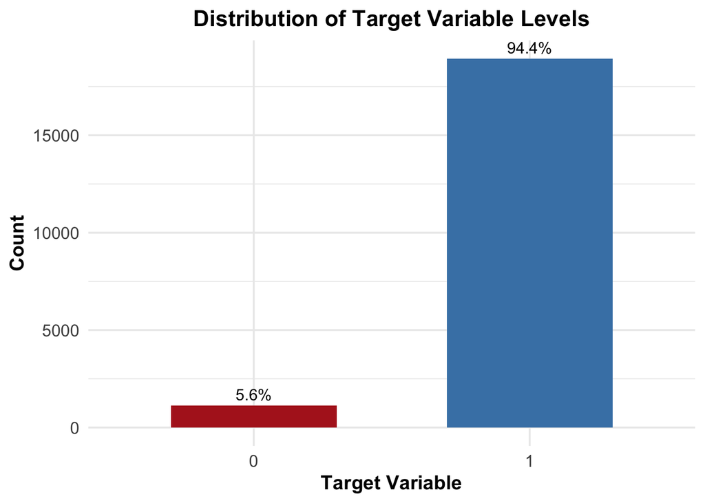

As expected, the random sample from the test data follows a very simmilar distribution to the entire dataset.

**Business Note:** We will now look at the same financial graphic we have done for the overall analysis but now with the model applied, meaning, only offering loans for the people the model predicted would repaid them. What would be the performance if we only conceded loans to people the model predict are going to pay back?

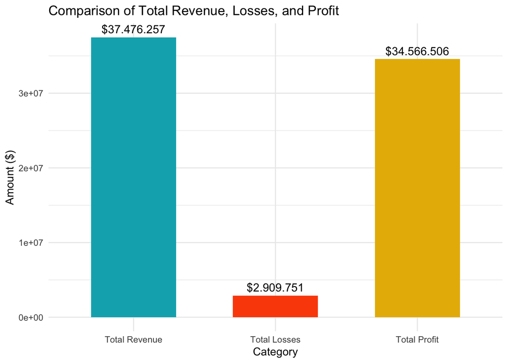

Although evaluating the financial impact using overall values is insightful, it can be challenging to compare these results with the current scenario since the total values differ due to the use of different datasets. As previously explained, the total values are not directly comparable because the model was applied to a subset of the data.

To address this, we will create a percentage-based graphic, similar to the one used earlier. This approach normalizes the results, presenting each metric (e.g., revenue, losses) as a percentage of total revenue. By using percentages, we can directly compare the financial outcomes with and without the model, regardless of the differences in dataset size or composition.

This percentage-based visualization will provide a clearer understanding of the relative financial benefits of implementing the model, enabling a fair and objective comparison with the current scenario.

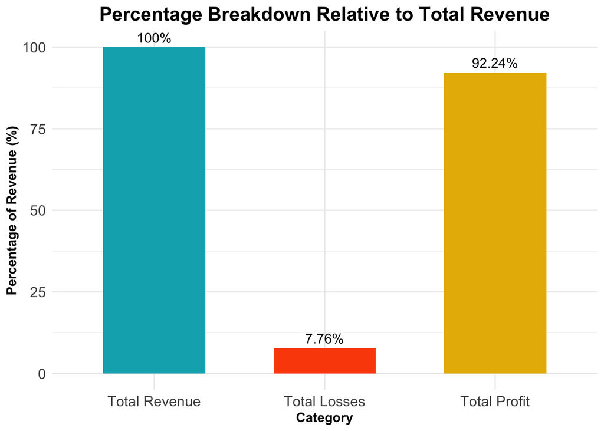

### a. Business Case Conclusion:

**Before Applying the Model:**

Prior to using the model, total losses accounted for **10.12%** of total revenue, reflecting a significant portion of loans that resulted in financial losses. Consequently, total profits represented **89.88%** of total revenue, indicating profitability but leaving room for improvement due to the impact of defaulted loans.

**After Applying the Model:**

With the predictive model implemented, total losses decreased to **7.76%** of total revenue, demonstrating a substantial reduction in financial losses by identifying and avoiding high-risk loans. Simultaneously, total profit increased to **92.24%** of total revenue, highlighting an improvement in profitability as a result of more informed loan approval decisions.

**Key Insights:**

1. **Reduction in Losses**: The model reduced losses by **2.36 percentage points** (from 10.12% to 7.76%), showcasing its effectiveness in minimizing exposure to default risks. While this percentage change might not initially appear significant, 2.36% of the overall revenue accounts to **3.912,393.604 dollars**.This financial impact highlights the meaningful contribution of the predictive model in improving the company’s bottom line.
2. **Increase in Profitability**: Profitability improved by **2.36 percentage points** (from 89.88% to 92.24%), reflecting the financial benefits of prioritizing loans with higher likelihoods of repayment.
3. **Enhanced Risk Management**: The predictive model successfully improved the balance between risk and reward by reducing the proportion of loans that result in losses while maintaining a high level of revenue generation.

The comparison underscores the financial advantages of implementing the predictive model. By leveraging its ability to filter high-risk loans, the company achieves a more optimized lending strategy, reducing losses and enhancing overall profitability. This demonstrates the model’s strategic value in improving the company’s financial outcomes and risk management practices.

### b. Lessons Learned and Improvement Points

Throughout this project, we encountered numerous decision points that involved meaningful trade-offs and required careful consideration. For example, determining whether to balance the dataset or deciding on the train/test split ratio were practical challenges that sparked valuable discussions. These decisions highlighted an essential aspect of data science: even in a mathematically precise and seemingly objective field, there are no universally “correct” answers. Instead, each decision depends on the context, objectives, and constraints of the project. Reflecting on these trade-offs underscored the importance of aligning technical choices with real-world implications and business goals.

Regarding areas for improvement, the primary limitation we faced was computational power. The dataset was exceptionally large, providing an opportunity to develop highly accurate and complex models. However, the lack of sufficient computational resources constrained our ability to explore more sophisticated approaches. For instance, it would have been valuable to implement a stepwise logistic regression or train a deeper Artificial Neural Network (ANN) with additional layers and neurons. These methods could have potentially yielded even better results but were beyond our computational capacity.

### c. Overall Project and Course Conclusion

The overarching conclusion of this report is that predictive models are revolutionizing industries and reshaping markets. However, the effectiveness of these models is intrinsically tied to the quality and relevance of their input data. As the volume of data being collected continues to grow exponentially, the potential for predictive models to become even more accurate and impactful is immense.

In the context of our specific project, we demonstrated how relatively simple predictive models can generate substantial value for a business with minimal implementation costs. The potential to increase profits by nearly 4 million dollars solely by integrating these models into decision-making processes is a striking outcome. It underscores the transformative power of data-driven strategies.

Lastly, this project serves as a reminder of the broader potential of advanced predictive analytics. If such results can be achieved by a team of university students with limited resources, one can only imagine the possibilities unlocked by cutting-edge predictive models deployed by industry leaders with access to high-end computational capabilities. These tools have the power to shape and transform entire industries, paving the way for smarter, more efficient, and highly innovative business strategies.